# Prueba

patricio zapata

06-08-2020

### Pregunta 1: Use las herramientas de dplyr para crear un nuevo data frame (df):

Con las siguientes variables: nombre de la película, nombre del director, nombre primer actor, número de críticas positivas, duración, cantidad bruta recaudada, lenguaje, presupuesto, año, puntuación IMDB, likes de la película y género predominante. - Elimine del df todas las observaciones que tengan alguna casilla vacía. - Ordénelo por año, del más reciente al más antiguo.

```r
data <-  data.frame(peli$Nombre_Pelicula,peli$Nombre_Director,peli$Nombre_Primer_Actor,peli$Criticas_Positivas,peli$Duracion,peli$Cantidad_Bruta_Recaudada,peli$Lenguaje,peli$Presupuesto,peli$Año,peli$Puntuacion_IMDB,peli$Likes_Pelicula,peli$Genero_Predominante)

#sapply(data, function(x) sum(is.na(x)))
datos <- na.omit(data)
#sapply(datos, function(x) sum(is.na(x)))


Muestra <- datos %>%
  dplyr::arrange(datos$peli.Año)

DT::datatable(Muestra)
```

|  | peli.Nombre_Pelicula | peli.Nombre_Director | peli.Nombre_Primer_Actor | peli.Criticas_Positivas | peli.Duracion | peli.Cantidad_Bruta_Recaudada | peli.Lenguaje | peli.Presupuesto | peli.Año | peli.Puntuacion_IMDB | peli.Likes_Pelicula | peli.Genero_Predominante |
| --- | --- | --- | --- | --- | --- | --- | --- | --- | --- | --- | --- | --- |
| 1 | The Broadway Melody | Harry Beaumont | Anita Page | 60 | 100 | 2808000 | English | 379000 | 1929 | 6 , 3 puntos | 167 | Musical |
| 2 | 42nd Street | Lloyd Bacon | Ginger Rogers | 80 | 89 | 2300000 | English | 439000 | 1933 | 7 , 7 puntos | 439 | Comedy |
| 3 | Top Hat | Mark Sandrich | Ginger Rogers | 80 | 81 | 3000000 | English | 609000 | 1935 | 7 , 8 puntos | 1000 | Comedy |
| 4 | Modern Times | Charles Chaplin | Paulette Goddard | 80 | 87 | 163245 | English | 1500000 | 1936 | 8 , 6 puntos | 0 | Comedy |
| 5 | Snow White and the Seven Dwarfs | William Cottrell | Adriana Caselotti | 70 | 83 | 184925485 | English | 2000000 | 1937 | 7 , 7 puntos | 0 | Animation |
| 6 | Gone with the Wind | Victor Fleming | Hattie McDaniel | 70 | 226 | 198655278 | English | 3977000 | 1939 | 8 , 2 puntos | 16000 | Drama |
| 7 | The Wizard of Oz | Victor Fleming | Margaret Hamilton | 80 | 102 | 22202612 | English | 2800000 | 1939 | 8 , 1 puntos | 14000 | Adventure |
| 8 | Pinocchio | Norman Ferguson | Mel Blanc | 70 | 88 | 84300000 | English | 2600000 | 1940 | 7 , 5 puntos | 0 | Animation |
| 9 | Fantasia | James Algar | Leopold Stokowski | 70 | 120 | 76400000 | English | 2280000 | 1940 | 7 , 8 puntos | 3000 | Animation |
| 10 | Duel in the Sun | King Vidor | Joseph Cotten | 60 | 144 | 20400000 | English | 8000000 | 1946 | 6 , 9 puntos | 403 | Drama |

[output cut: 3060 more lines]

### Pregunta 2: Como interesa estudiar la puntuación de la película, debe

transformar la variable Puntuacion_IMDB, ya que esta cuenta con un formato no numérico. Cree una variable llamada Puntuacion que tome solo la puntuación en formato numérico a partir de Puntuacion_IMDB. Elimine la variable Puntuacion_IMDB de su df. Finalmente, construya el objeto prom_puntuacion que contenga la puntuación promedio para cada tipo de género predominante.

```r
DOS <- Muestra %>%
    dplyr::mutate(peli.Puntuacion_IMDB   = gsub(" , ", "", peli.Puntuacion_IMDB ),
                  peli.Puntuacion_IMDB   = gsub(" puntos", "", peli.Puntuacion_IMDB ),
                Puntuacion = as.numeric(peli.Puntuacion_IMDB ))
muestra2 <- select (DOS,-peli.Puntuacion_IMDB)

#str(muestra2)

ptt_promedio <- muestra2 %>%
  dplyr::group_by(peli.Genero_Predominante ) %>%
  dplyr::summarise(Puntuacion = round(mean(Puntuacion, na.rm = TRUE), 0))
DT::datatable(ptt_promedio)
```

|  | peli.Genero_Predominante | Puntuacion |
| --- | --- | --- |
| 1 | Action | 57 |
| 2 | Adventure | 61 |
| 3 | Animation | 57 |
| 4 | Biography | 62 |
| 5 | Comedy | 57 |
| 6 | Crime | 65 |
| 7 | Documentary | 62 |
| 8 | Drama | 61 |
| 9 | Family | 65 |
| 10 | Fantasy | 57 |

[output cut: 7 more lines]

### Pregunta 3: Use la librería ggplot2 para construir un gráfico de la

distribución de la variable Puntuacion y un gráfico que permita comparar la distribución de la puntuación por género predominante. Comente.

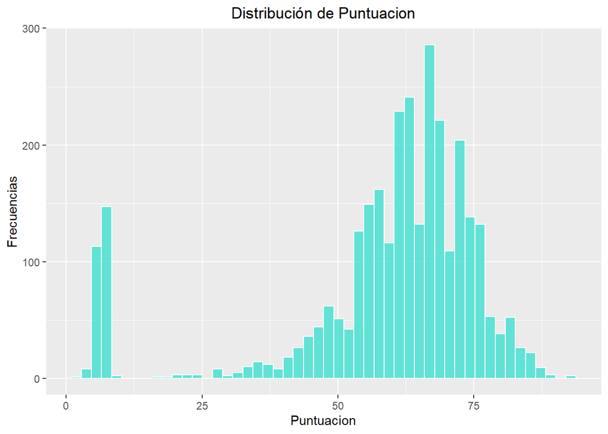

```r
ggplot(data = muestra2, aes(x = Puntuacion)) +
  geom_histogram(bins = 50, alpha = 0.8, color = "white", fill = "turquoise") +
  xlab("Puntuacion") +
  ylab("Frecuencias") +
  ggtitle("Distribución de Puntuacion") +
  theme(plot.title = element_text(hjust = 0.5))
```

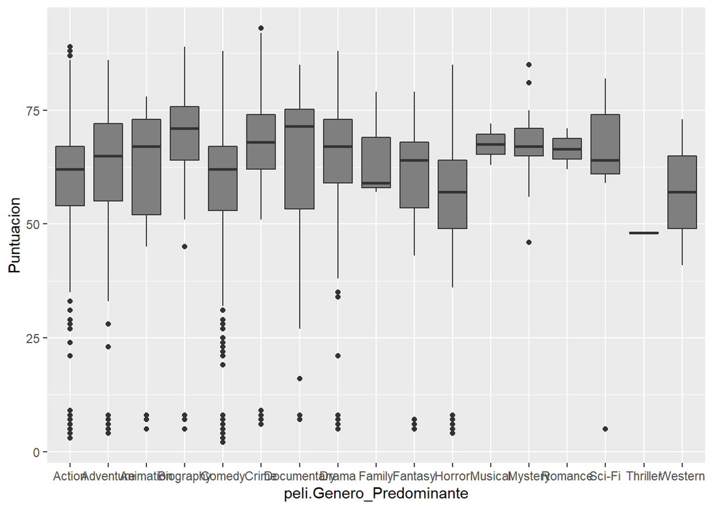

```r
#la categoria mas heterogeneas a los datos documenary y  y las mas homoe4nea  thriller
ggplot(data = muestra2, aes(x = Puntuacion, y = peli.Genero_Predominante, fill = Puntuacion)) +
  geom_boxplot() +
  coord_flip()+
  theme(legend.position="none")
```

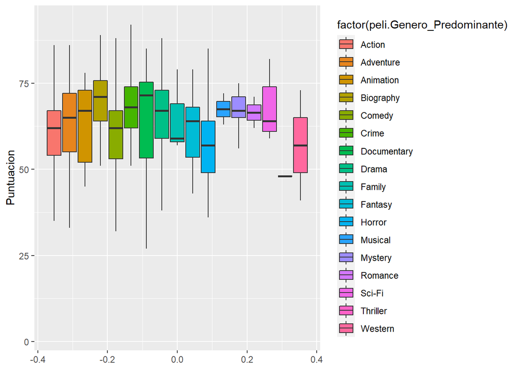

```r
ggplot(data = muestra2, aes(y = Puntuacion, fill = factor(peli.Genero_Predominante))) +
  geom_boxplot(outlier.shape = NA)
```

### Pregunta 4: Analice de manera gráfica la correlación de Puntuacion con

el resto de las variables cuantitativas. Además, analice a través de una matriz gráfica, la dispersión y distribución de las variables. Comente.

```r
tres = na.omit(muestra2[, -c(1,2,3,7,11)])
cor_tres = cor(tres)
cor_tres
```

```
##                               peli.Criticas_Positivas peli.Duracion
## peli.Criticas_Positivas                    1.00000000     0.3360473
## peli.Duracion                              0.33604734     1.0000000
## peli.Cantidad_Bruta_Recaudada              0.23810066     0.2838748
## peli.Presupuesto                           0.06423598     0.3034006
## peli.Año                                  -0.14507274    -0.1056986
## peli.Likes_Pelicula                        0.25395454     0.2552143
## Puntuacion                                 0.42639650     0.1589305
##                               peli.Cantidad_Bruta_Recaudada peli.Presupuesto
## peli.Criticas_Positivas                          0.23810066       0.06423598
## peli.Duracion                                    0.28387481       0.30340060
## peli.Cantidad_Bruta_Recaudada                    1.00000000       0.64586808
## peli.Presupuesto                                 0.64586808       1.00000000
## peli.Año                                         0.04891112       0.23882735
## peli.Likes_Pelicula                              0.38573067       0.33986972
## Puntuacion                                       0.12188282       0.03309623
##                                  peli.Año peli.Likes_Pelicula  Puntuacion
## peli.Criticas_Positivas       -0.14507274           0.2539545  0.42639650
## peli.Duracion                 -0.10569858           0.2552143  0.15893053
## peli.Cantidad_Bruta_Recaudada  0.04891112           0.3857307  0.12188282
## peli.Presupuesto               0.23882735           0.3398697  0.03309623
## peli.Año                       1.00000000           0.3005748 -0.08738299
## peli.Likes_Pelicula            0.30057481           1.0000000  0.11604592
## Puntuacion                    -0.08738299           0.1160459  1.00000000
```

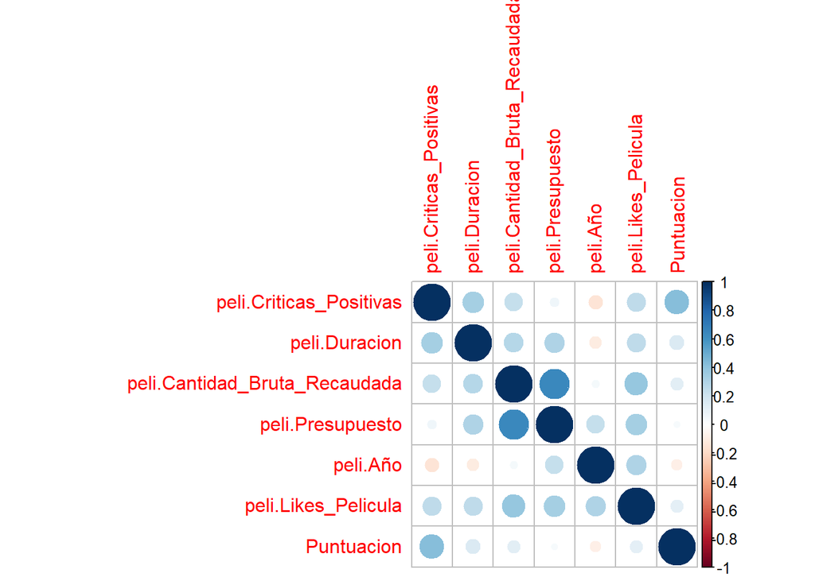

```r
corrplot(cor_tres)
```

```r
# el resto de las variables cuantitativas. Además, analice a través de una
# matriz gráfica, la dispersión y distribución de las variables. Comente.
str(muestra2)
```

```
## 'data.frame':    3070 obs. of  12 variables:
##  $ peli.Nombre_Pelicula         : chr  "The Broadway Melody " "42nd Street " "Top Hat " "Modern Times " ...
##  $ peli.Nombre_Director         : chr  "Harry Beaumont" "Lloyd Bacon" "Mark Sandrich" "Charles Chaplin" ...
##  $ peli.Nombre_Primer_Actor     : chr  "Anita Page" "Ginger Rogers" "Ginger Rogers" "Paulette Goddard" ...
##  $ peli.Criticas_Positivas      : num  60 80 80 80 70 70 80 70 70 60 ...
##  $ peli.Duracion                : num  100 89 81 87 83 226 102 88 120 144 ...
##  $ peli.Cantidad_Bruta_Recaudada: num  2.81e+06 2.30e+06 3.00e+06 1.63e+05 1.85e+08 ...
##  $ peli.Lenguaje                : chr  "English" "English" "English" "English" ...
##  $ peli.Presupuesto             : num  379000 439000 609000 1500000 2000000 ...
##  $ peli.Año                     : num  1929 1933 1935 1936 1937 ...
##  $ peli.Likes_Pelicula          : num  167 439 1000 0 0 16000 14000 0 3000 403 ...
##  $ peli.Genero_Predominante     : chr  "Musical" "Comedy" "Comedy" "Comedy" ...
##  $ Puntuacion                   : num  63 77 78 86 77 82 81 75 78 69 ...
```

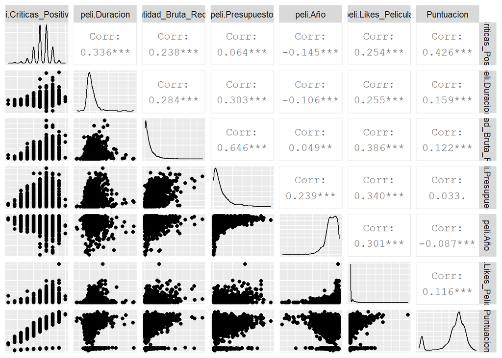

```r
ggpairs(tres,
        axisLabels = "none")
```

```r
#g2 <- ggplot(data = viv, aes(x = longitud, y = latitud,  col = prox_oceano))
#g2 + geom_point()
```